# STATS_HomeWork_2

2023-09-17

1. 1. Here, I’m going to analyse the PrisonStress data set from th r package. It has total of 26 observations with Subject, Group, PFFbefore and PSSafter columns which tell us the prisoner stress level in and out of the jail along with the group that they belong to.

```r
library(PairedData)
data(PrisonStress)
str(PrisonStress)
```

```
## 'data.frame':    26 obs. of  4 variables:
##  $ Subject  : Factor w/ 26 levels "A1","A2","A3",..: 1 3 4 5 6 7 8 9 10 11 ...
##  $ Group    : Factor w/ 2 levels "Control","Sport": 2 2 2 2 2 2 2 2 2 2 ...
##  $ PSSbefore: num  25 17 12 21 29 28 21 18 20 29 ...
##  $ PSSafter : num  13 15 13 22 25 24 19 19 24 21 ...
```

```r
#Filtering the dataseaet based on the group
sport_group <- subset(PrisonStress, PrisonStress$Group == "Sport")
control_group <- subset(PrisonStress, PrisonStress$Group == "Control")
```

The above two populations are matched pair We need to figure out whether the training helped the prisoners in terms of the stress levels. For that we can check the mean difference between the two provided groups. We can perform various tests out of which we going to perform the strong test which is t test. For the t-test, we need the data to be normal and equal variance Let’s test them for both pssbefore as well as pssafter of difference between them

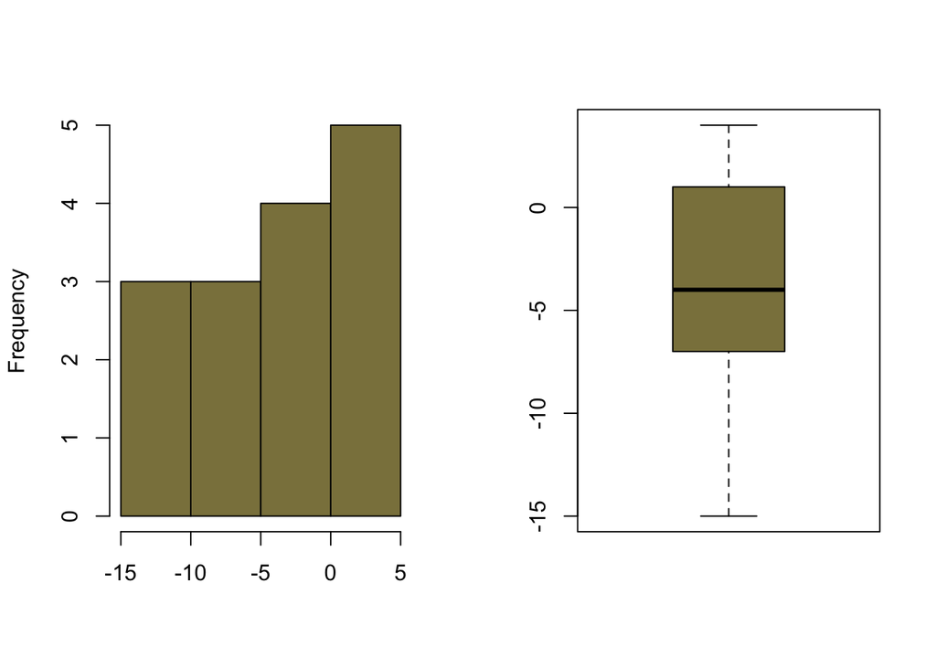

```r
difference_data = sport_group$PSSafter - sport_group$PSSbefore
#pssbefore
par(mfrow=c(1,2))
hist(difference_data, main = "", xlab ="",
     col = "lightgoldenrod4", border = "black")
boxplot(difference_data, main = NA, xlab = "", col = "lightgoldenrod4")
```

From the above chart we can observe that the data was normal. Let’s statistically prove them by using the skewness and shapiro-wilk test since the data is discrete.

```r
library(e1071)

cat("difference_data \n")
```

```
## difference_data
```

```r
skewness(difference_data)
```

```
## [1] -0.4023306
```

```r
cat("difference_data shapiro-wilktest\n")
```

```
## difference_data shapiro-wilktest
```

```r
shapiro.test(difference_data)
```

```
##
##  Shapiro-Wilk normality test
##
## data:  difference_data
## W = 0.95267, p-value = 0.5674
```

```r
var.test(sport_group$PSSbefore, sport_group$PSSafter)
```

```
##
##  F test to compare two variances
##
## data:  sport_group$PSSbefore and sport_group$PSSafter
## F = 1.175, num df = 14, denom df = 14, p-value = 0.767
## alternative hypothesis: true ratio of variances is not equal to 1
## 95 percent confidence interval:
##  0.394499 3.499989
## sample estimates:
## ratio of variances
##            1.17505
```

The data provides insufficient evidence to reject $H_0$, and conclude equal population variances. As both the normality and equal variance conditions satisfies we can perform t-test. Where following is the null hypothesis and respective alternative hypothesis.

$H_{0}: \mu_{1} =\mu_{2}$ versus $H_{1}: \mu_{1} \ne \mu_{2}$.

```r
t.test(sport_group$PSSbefore, sport_group$PSSafter, paired = TRUE)
```

```
##
##  Paired t-test
##
## data:  sport_group$PSSbefore and sport_group$PSSafter
## t = 2.6842, df = 14, p-value = 0.0178
## alternative hypothesis: true mean difference is not equal to 0
## 95 percent confidence interval:
##  0.7904329 7.0762338
## sample estimates:
## mean difference
##        3.933333
```

The mean sample difference is $\overline{d} = 3.933333$.

**Effect size** tells us how meaningful the relationship between variables or the difference between groups is, i.e., it indicates the practical significance of a research outcome. A large effect size means that a research finding has practical significance, whereas the medium effect size indicates the noticeable significant while a small effect size indicates limited practical applications.

We can obtain the effect size using Cohen’s D. As expected, the effect size of the difference between PSSbefore and PSSafter is medium.

```r
library(effsize)
```

```r
# Cohen's d for paired $t$ procedure
cohen.d(sport_group$PSSbefore, sport_group$PSSafter, paired = TRUE)
```

```
##
## Cohen's d
##
## d estimate: 0.5440526 (medium)
## 95 percent confidence interval:
##      lower      upper
## 0.09920296 0.98890233
```

The paired $t$-procedure is valid for the data and is more powerful.

2. Here, we are going to compare both the means of sport and control groups at the time exit from the data. Following are some of the observations that we drew Graphically and numerically.

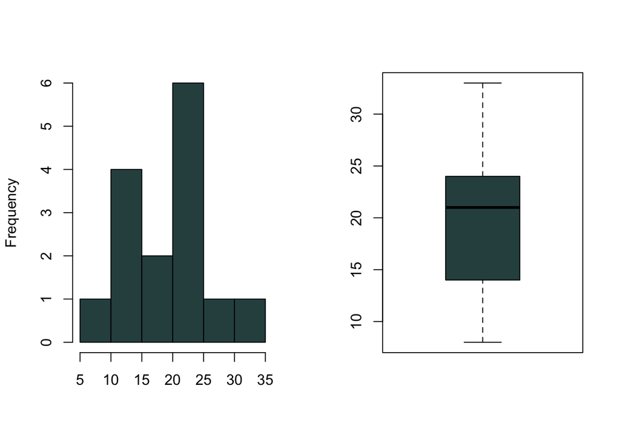

```r
#pssafter
par(mfrow=c(1,2))
hist(sport_group$PSSafter, main = "", xlab ="",
     col = "darkslategrey", border = "black")
boxplot(sport_group$PSSafter, main = NA, xlab = "", col = "darkslategrey")
```

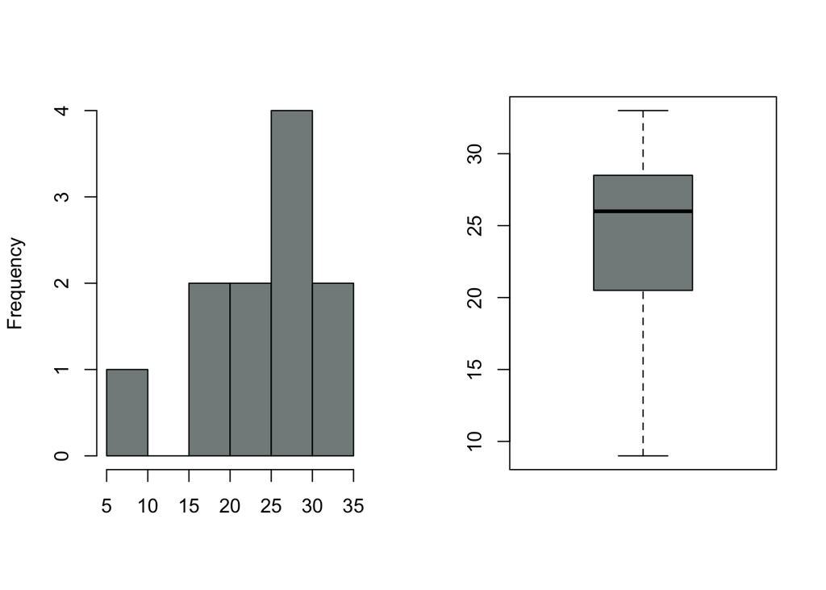

```r
#control_group_after
par(mfrow=c(1,2))
hist(control_group$PSSafter, main = "", xlab ="",
     col = "azure4", border = "black")
boxplot(control_group$PSSafter, main = NA, xlab = "", col = "azure4")
```

```r
cat("sport_group$PSSbefore \n")
```

```
## sport_group$PSSbefore
```

```r
skewness(sport_group$PSSafter)
```

```
## [1] 0.08374067
```

```r
cat("sport_group$PSSafter \n")
```

```
## sport_group$PSSafter
```

```r
skewness(control_group$PSSafter)
```

```
## [1] -0.5792417
```

```r
cat("shapiro.test(sport_group$PSSbefore \n")
```

```
## shapiro.test(sport_group$PSSbefore
```

```r
shapiro.test(sport_group$PSSafter)
```

```
##
##  Shapiro-Wilk normality test
##
## data:  sport_group$PSSafter
## W = 0.97338, p-value = 0.9046
```

```r
cat("shapiro.test(sport_group$PSSafter \n")
```

```
## shapiro.test(sport_group$PSSafter
```

```r
shapiro.test(control_group$PSSafter)
```

```
##
##  Shapiro-Wilk normality test
##
## data:  control_group$PSSafter
## W = 0.94481, p-value = 0.5786
```

Even though the data is left skewed by the p-value obtained from the shapiro-wilk test confirms that the data upholds normality as the p-value is greater than the 0.05.

From the following normal q-q plot shows that the points fall approximately on a straight line.

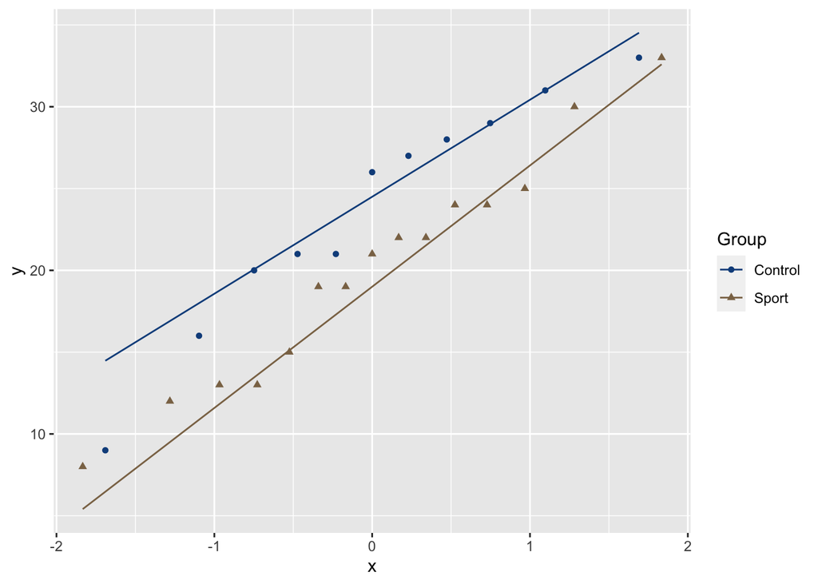

```r
PSS <-  PrisonStress[c("Group", "PSSafter")]

my_colors <- c("dodgerblue4", "burlywood4")
ggplot(PSS, aes(sample=PSSafter,shape=Group, color=Group)) + stat_qq()+ stat_qq_line() + scale_color_manual(values = my_colors)
```

Now, lets test for the variances both graphically as well as statistically.

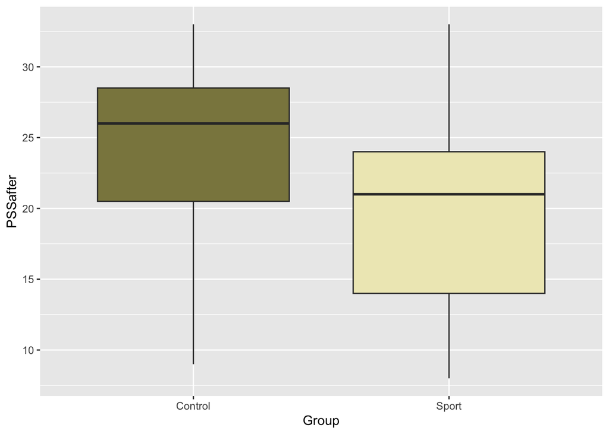

```r
my_colors <- c("khaki4", "lemonchiffon2")
ggplot(PSS, aes(x = Group, y = PSSafter, fill = Group)) +
  geom_boxplot(show.legend = FALSE) +  # Use fill aesthetic and hide legend
  scale_fill_manual(values = my_colors)  # Specify custom colors
```

The spreads of groups were little different from the above side-by-side box plot. Since the normalit assumption holds for both the data lets conduct f-test

3. Since the normality assumption holds for both populations, we use the $F$-test for checking $H_{0}: \sigma_{1}^{2}=\sigma_{2}^{2}$ versus $H_1: \sigma^2_1 \neq \sigma^2_2$. The test statistic is the ratio of the sample variances:

$$F=S_{1}^{2}/S_{2}^{2} \sim F_{n_{1}-1, n_{2}-1}.$$

```r
# F-test for equal variance
var.test(control_group$PSSafter, sport_group$PSSafter)
```

```
##
##  F test to compare two variances
##
## data:  control_group$PSSafter and sport_group$PSSafter
## F = 1.0609, num df = 10, denom df = 14, p-value = 0.8951
## alternative hypothesis: true ratio of variances is not equal to 1
## 95 percent confidence interval:
##  0.3371169 3.7664880
## sample estimates:
## ratio of variances
##            1.06086
```

From the above p-value we fail to reject the null hypothesis and can confirm that the two populations variances are equal.

1.d. As both normal and the equal variance holds we can continue with the pooled t-test

```r
t.test(PSSafter ~ Group, data=PSS, alternative = c("greater"),var.equal = TRUE)
```

```
##
##  Two Sample t-test
##
## data:  PSSafter by Group
## t = 1.3424, df = 24, p-value = 0.09601
## alternative hypothesis: true difference in means between group Control and group Sport is greater than 0
## 95 percent confidence interval:
##  -1.023091       Inf
## sample estimates:
## mean in group Control   mean in group Sport
##              23.72727              20.00000
```

From the above pooled t-test the p value is greater than the $\alpha$ value of 0.05 and so we accept the null hypothesis and conclude that there is **no considerable difference between the two populations(control and sport) at the time of exit.**

1.e. **Effect size** tells us how meaningful the relationship between variables or the difference between groups is, i.e., it indicates the practical significance of a research outcome. A large effect size means that a research finding has practical significance, whereas the medium effect size indicates the noticeable significant while a small effect size indicates limited practical applications.

We can obtain the effect size using Cohen’s D. As expected, the effect size of the difference between control and the sport groups of PSSafter is medium and so there will be considerable practical significance.

```r
#to calculate the effect zise
cohen.d(control_group$PSSafter, sport_group$PSSafter, pooled = TRUE)
```

```
##
## Cohen's d
##
## d estimate: 0.5328796 (medium)
## 95 percent confidence interval:
##      lower      upper
## -0.3004769  1.3662361
```

2. Loblolly contains trees data with total of 84 observations along with information such as the height, age and seed. Height describes the heigth of the tree, age is the age of the tree where as the seed indicates us the Id of the tree. From the data it is clear that the age information linked to the id of a in a interval of 5 years with that we can confirm that the data we are going to work on this problem is dependent.

```r
str(Loblolly)
```

```
## Classes 'nfnGroupedData', 'nfGroupedData', 'groupedData' and 'data.frame':   84 obs. of  3 variables:
##  $ height: num  4.51 10.89 28.72 41.74 52.7 ...
##  $ age   : num  3 5 10 15 20 25 3 5 10 15 ...
##  $ Seed  : Ord.factor w/ 14 levels "329"<"327"<"325"<..: 10 10 10 10 10 10 13 13 13 13 ...
##  - attr(*, "formula")=Class 'formula'  language height ~ age | Seed
##   .. ..- attr(*, ".Environment")=<environment: R_EmptyEnv>
##  - attr(*, "labels")=List of 2
##   ..$ x: chr "Age of tree"
##   ..$ y: chr "Height of tree"
##  - attr(*, "units")=List of 2
##   ..$ x: chr "(yr)"
##   ..$ y: chr "(ft)"
```

As we need to group the trees data based on the age of the tree of 20 and 25, filtering the data.

```r
loblolly_20 <- subset(Loblolly, Loblolly$age == "20")
loblolly_25 <- subset(Loblolly, Loblolly$age == "25")

diff_loblolly <- loblolly_25$height - loblolly_20$height
```

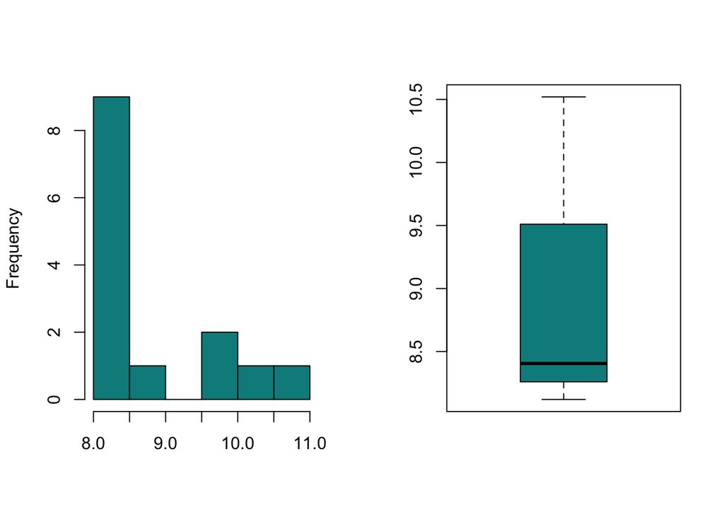

```r
par(mfrow=c(1,2))
hist(diff_loblolly, main = "", xlab ="",
     col = "cyan4", border = "black")
boxplot(diff_loblolly, main = NA, xlab = "", col = "cyan4")
```

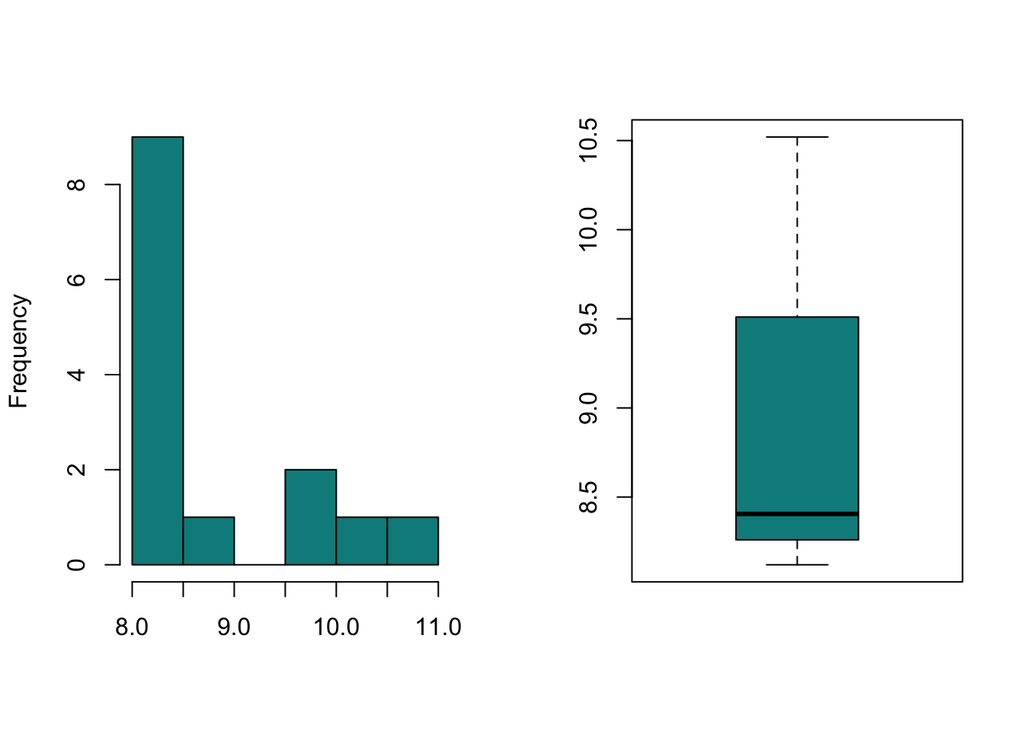

```r
diff_loblolly <- loblolly_25$height - loblolly_20$height

par(mfrow=c(1,2))
hist(diff_loblolly, main = "", xlab ="",
     col = "cyan4", border = "black")
boxplot(diff_loblolly, main = NA, xlab = "", col = "cyan4")
```

```r
cat("skewness loblolly_20$height \n")
```

```
## skewness loblolly_20$height
```

```r
skewness(diff_loblolly)
```

```
## [1] 0.978943
```

```r
cat("loblolly_20$height \n")
```

```
## loblolly_20$height
```

```r
shapiro.test(diff_loblolly)
```

```
##
##  Shapiro-Wilk normality test
##
## data:  diff_loblolly
## W = 0.76254, p-value = 0.001781
```

From the above chart and results we can confirm that the data is not following normality. We my apply log10 transformation on the data however here we are taking the difference of the data which it will not work as log transformation is for the normality.

As the normality asumptions was not satisfied we can go with the Paired Fisher’s sign procedure

```r
library("BSDA")
SIGN.test(loblolly_25$height,loblolly_20$height)
```

```
##
##  Dependent-samples Sign-Test
##
## data:  loblolly_25$height and loblolly_20$height
## S = 14, p-value = 0.0001221
## alternative hypothesis: true median difference is not equal to 0
## 95 percent confidence interval:
##  8.253363 9.548165
## sample estimates:
## median of x-y
##         8.405
##
## Achieved and Interpolated Confidence Intervals:
##
##                   Conf.Level L.E.pt U.E.pt
## Lower Achieved CI     0.9426 8.2600 9.5100
## Interpolated CI       0.9500 8.2534 9.5482
## Upper Achieved CI     0.9871 8.2200 9.7400
```

For the effect size to calculate we can apply Wilcoxon Signed-Rank Effect Size for the fishers sign test as it is non-parametric

```r
data <- diff_loblolly

# Calculate the absolute differences
differences <- diff(data)
# Rank the absolute differences (ignore the sign)
ranked_differences <- rank(abs(differences))
# Calculate the sum of ranks for positive differences
positive_sum_ranks <- sum(ranked_differences[differences > 0])
# Calculate the sum of ranks for negative differences
negative_sum_ranks <- sum(ranked_differences[differences < 0])
# Determine the smaller of the two sums of ranks
smaller_sum_ranks <- min(positive_sum_ranks, negative_sum_ranks)
# Calculate the effect size (r)
N <- length(data) - 1  # Number of pairs
effect_size_r <- smaller_sum_ranks / N
# Print the effect size (r)
print(effect_size_r)
```

```
## [1] 3.230769
```

3. For the given two independent samples if the conclusion was drawn from two-sample pooled t-test that means that the following assumptions were already satisfied such as normality and the equal variances whereas the Wilcoxon’s rank-sum test is specifically suitable for the case where the data not even symmetry. Moreover, the **two-sample pooled t-test is the most powerful test** as it provides the precise information about the mean differences on comparison with the **Wilcoxon’s rank-sum test** whereas it is the **least powerful test**.

I would recommend, two-sample pooled t-test when the assumptions such as the normality and the equal variances of the data was met as as it is more statistically powerful if at all the assumptions were not satisfied including the symmetry we can choose Wilcoxon’s rank-sum test.

4. P-value controversy and its understanding is one of the majorly debated topics in the statistical field because of the **nuanced interpretation of the p-values** which sometimes even **mislead the data** to the wrong dirrection. It is true that the p-values are helpful for the taking decisions on the data however it should not be only considered as primary concluder as practical significance also shows considerable effect on the data. One can take **effect sizes, confidence intervals, domain knowledge** in conjunction with the p-values to take a concrete decision on the data. Moreover, overlying solely on the p-values could lead to **p-hacking** or **overly definitive conclusions**.

As an emerging data scientist, I would like to recognize the **importance** of a more **comprehensive** interpretation of the data such as the effect size, context, practical significance along side the p-values to make a resonable decisions and analysis on the data. Most importantly, **updating myself** on the latest methods, practices and embracing a **holistic approach** to the data analysis where p-values are just one tool in the toolbox.